# Process Quast Output

Sander Wuyts

25 July 2018

# N50 and total genome length

Let’s check the distribution of the N50 values:

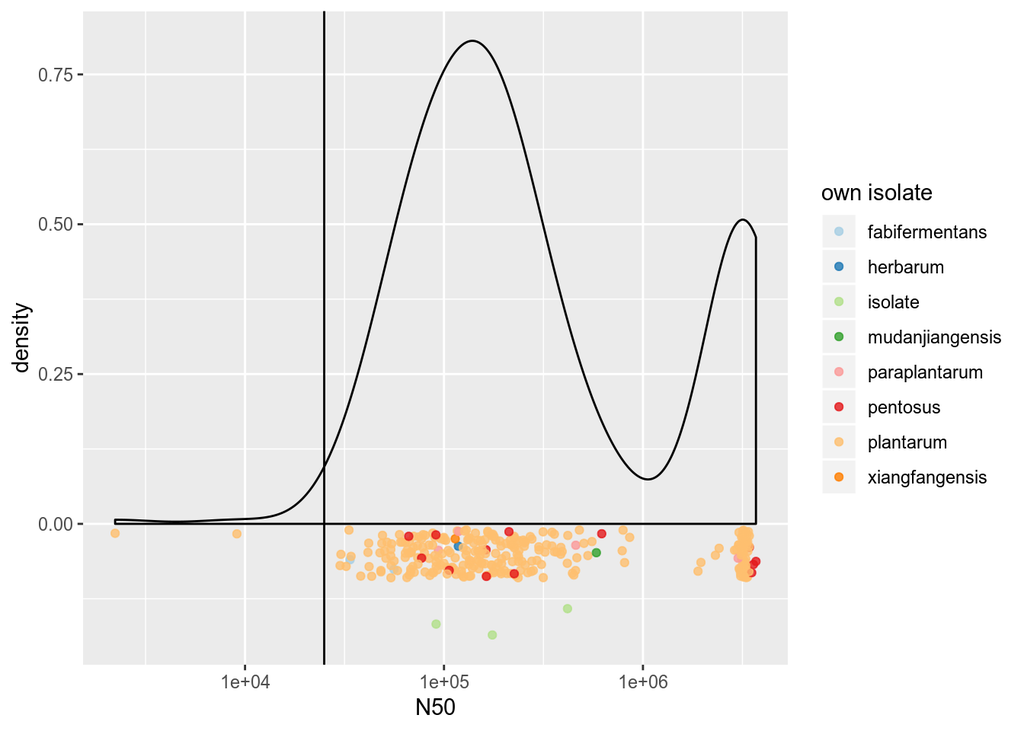

There’s two with a very short N50. Let’s put a cutoff of N50 > 25000 bp to exclude this one

Let’s plot the quality parameters: N50 values and number of N’s per 100.000 bases.

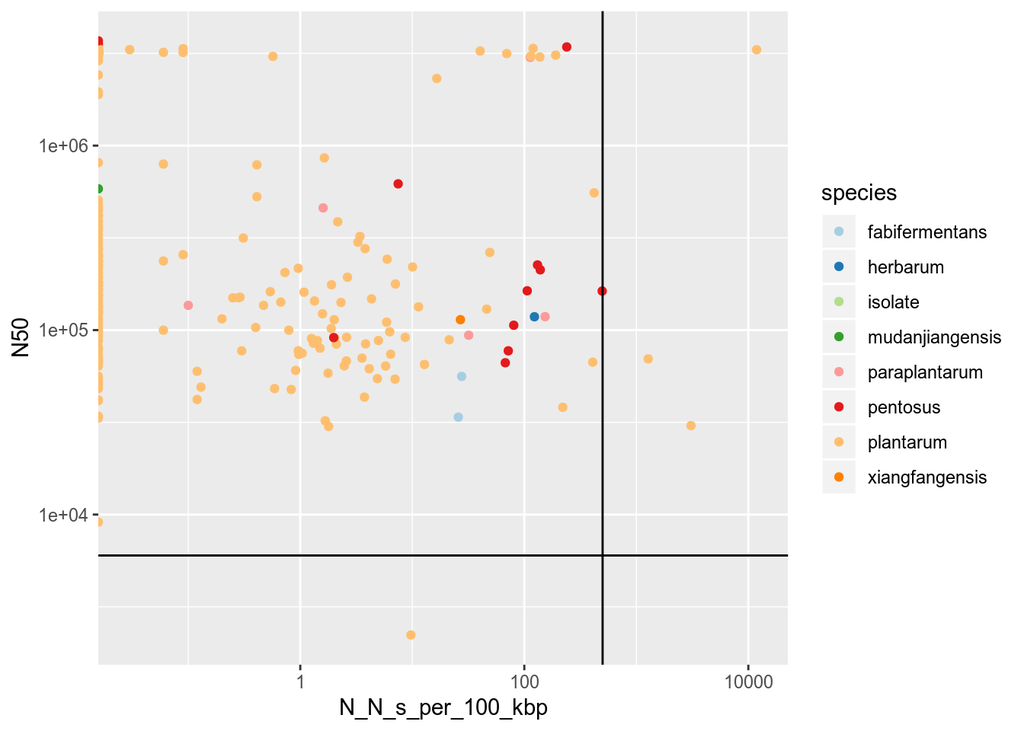

Let’s put a cutoff at around 500.

```r
# Make extra variable with selected genomes
genomeTable$useGenome = genomeTable$N50>25000 & genomeTable$N_N_s_per_100_kbp<500

# Summary
sprintf("total number of genomes: %i", nrow(report))
```

```
## [1] "total number of genomes: 310"
```

```r
sprintf("number of genomes that pass QC: %i", sum(genomeTable$useGenome))
```

```
## [1] "number of genomes that pass QC: 305"
```

Now we can plot genome parameters: GC content and genome length:

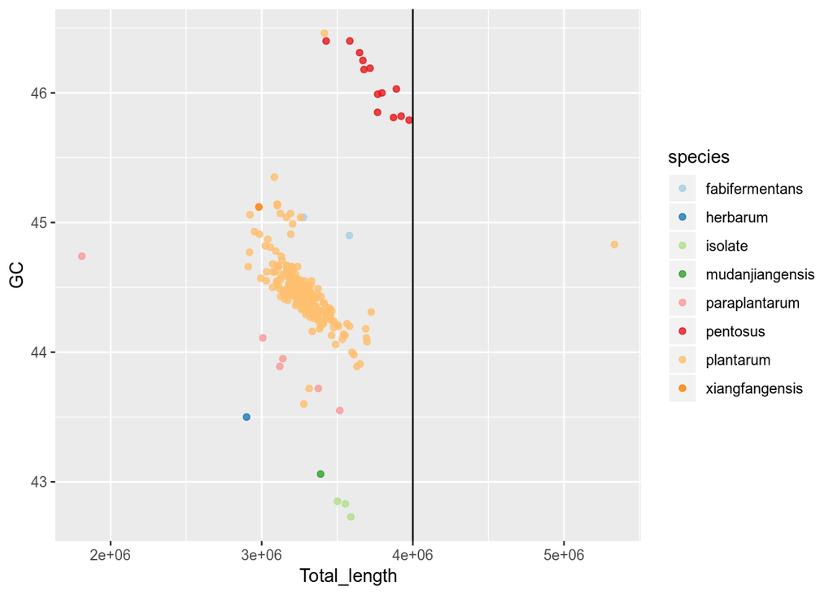

There’s one with a much bigger genome size than the rest. Looking at other parameters of this genome it seems that it has no contigs higher than 10 000 bp. All the rest of the assemblies do. This is also the one with the very low N50.

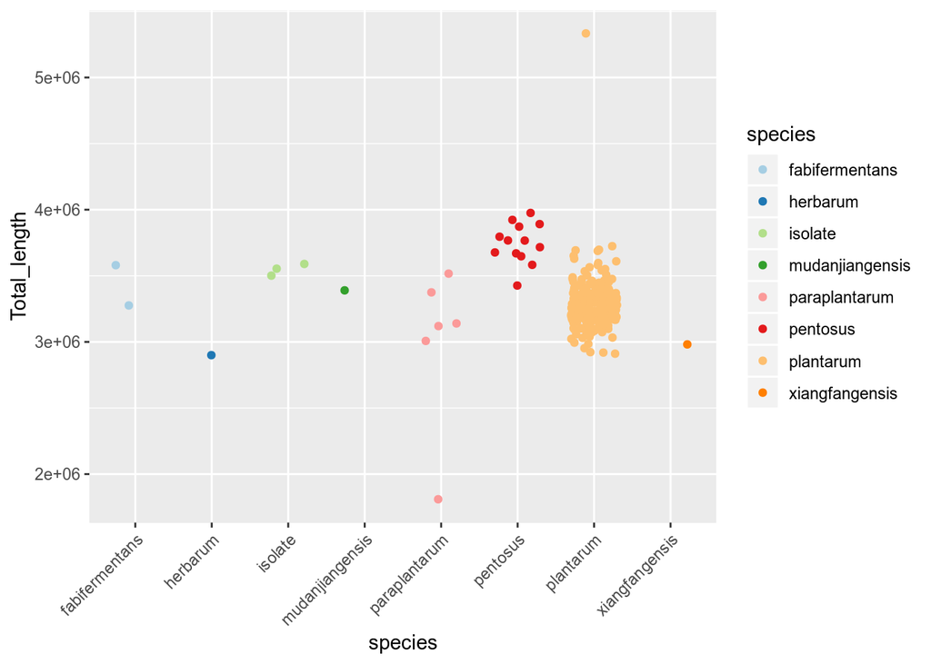

```r
ggplot(data=genomeTable, aes(x=species, y=Total_length, col=species)) +
  geom_jitter(height=0, width=0.3) +
  scale_color_brewer(palette="Paired", name="species") +
  theme(axis.text.x = element_text(angle=45,hjust=1,vjust=1))
```

In addition, there’s one paraplantarum with a very low genome length compared to the rest. Let’s also remove that one

```r
# Make extra variable with selected genomes
genomeTable$useGenome = genomeTable$useGenome & genomeTable$Total_length<4.5e6 & genomeTable$Total_length>2e6

# Summary
sprintf("total number of genomes: %i", nrow(report))
```

```
## [1] "total number of genomes: 310"
```

```r
sprintf("number of genomes that pass QC: %i", sum(genomeTable$useGenome))
```

```
## [1] "number of genomes that pass QC: 304"
```

Make the genometable file!

# Some other standard plots

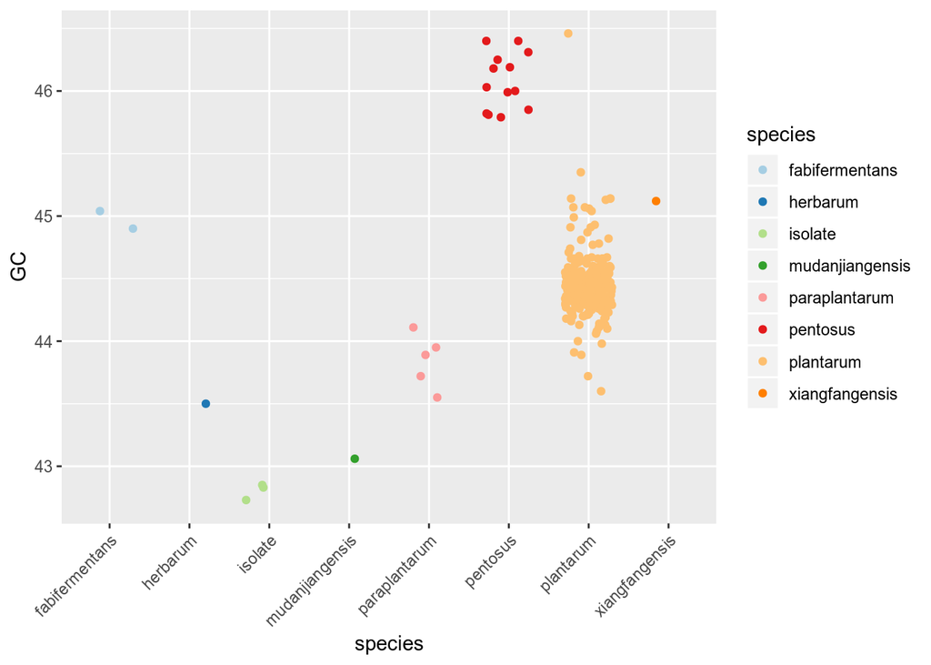

```r
ggplot(data=genomeTable[genomeTable$useGenome,], aes(x=species, y=GC, col=species)) +
  geom_jitter(height=0, width=0.3) +
  scale_color_brewer(palette="Paired", name="species") +
  theme(axis.text.x = element_text(angle=45,hjust=1,vjust=1))
```

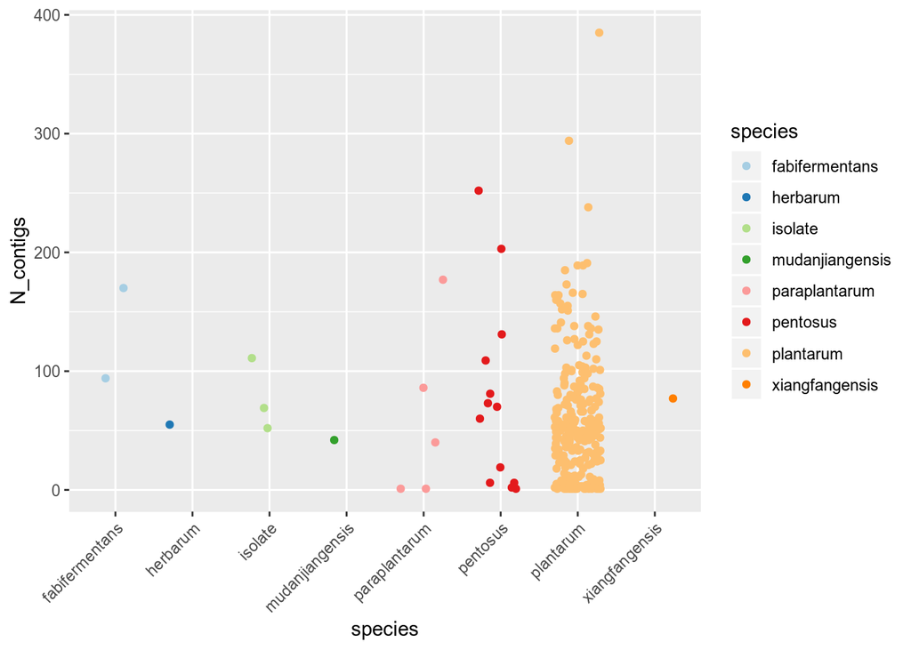

```r
ggplot(data=genomeTable[genomeTable$useGenome,], aes(x=species, y=N_contigs, col=species)) +
  geom_jitter(height=0, width=0.3) +
  scale_color_brewer(palette="Paired", name="species") +
  theme(axis.text.x = element_text(angle=45,hjust=1,vjust=1))
```

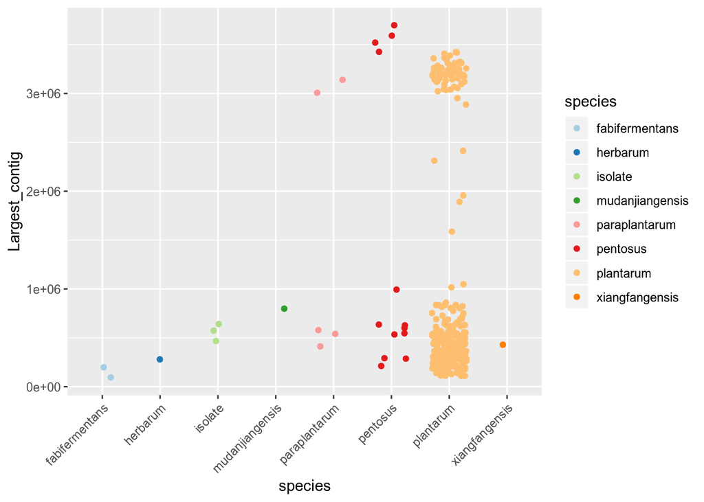

```r
ggplot(data=genomeTable[genomeTable$useGenome,], aes(x=species, y=Largest_contig, col=species)) +
  geom_jitter(height=0, width=0.3) +
  scale_color_brewer(palette="Paired", name="species") +
  theme(axis.text.x = element_text(angle=45,hjust=1,vjust=1))
```

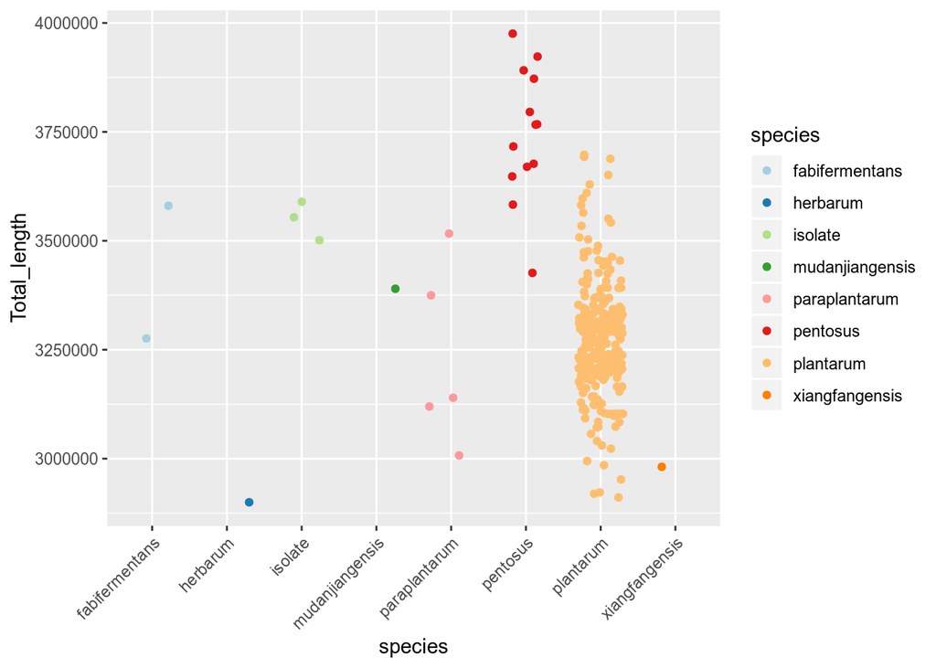

```r
ggplot(data=genomeTable[genomeTable$useGenome,], aes(x=species, y=Total_length, col=species)) +
  geom_jitter(height=0, width=0.3) +
  scale_color_brewer(palette="Paired", name="species") +
  theme(axis.text.x = element_text(angle=45,hjust=1,vjust=1))
```

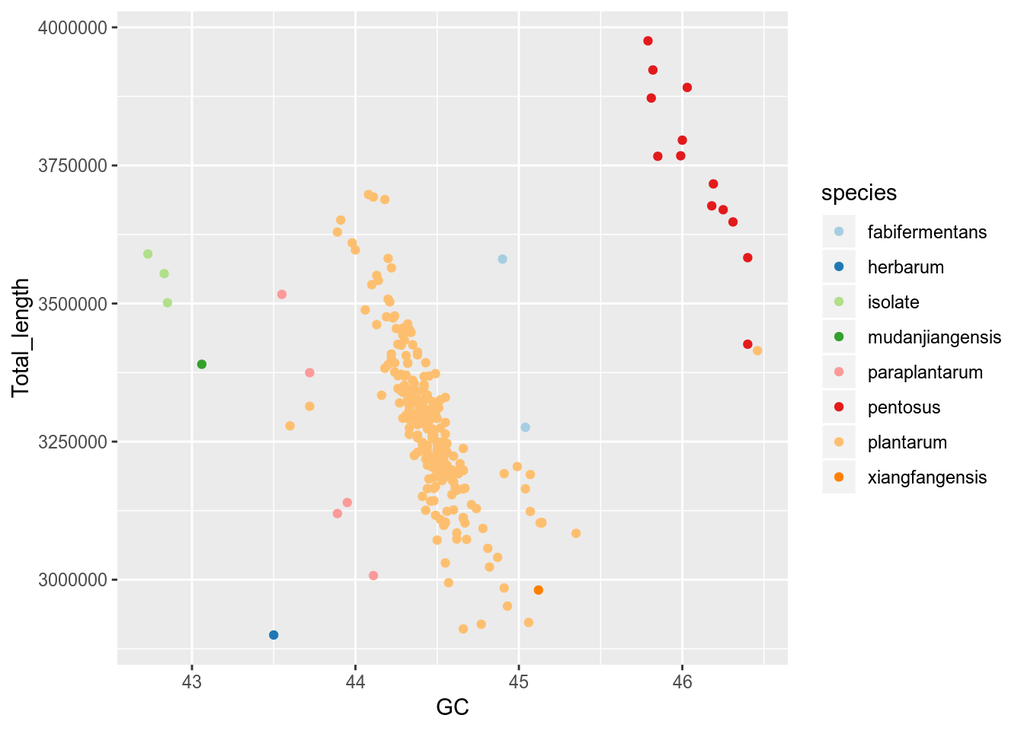

```r
ggplot(data=genomeTable[genomeTable$useGenome,], aes(x=GC, y=Total_length, col=species)) +
  geom_point() +
  scale_color_brewer(palette="Paired", name="species")
```

Some conclusions:

- Plantarum has a wide GC range
- There’s one Plantarum strain which is probably a pentosus strain

# Statistics for paper

Amount per species

```r
genomeTable %>%
  filter(useGenome == T) %>%
  group_by(species) %>%
  summarise(count = n())
```

```
## # A tibble: 8 x 2
##   species         count
##   <chr>           <int>
## 1 fabifermentans      2
## 2 herbarum            1
## 3 isolate             3
## 4 mudanjiangensis     1
## 5 paraplantarum       5
## 6 pentosus           13
## 7 plantarum         278
## 8 xiangfangensis      1
```

Amount of lactobacilli

```bash
grep "Lactobacillus" ../02_download_ncbi_genomes/assembly_summary.txt  > ../02_download_ncbi_genomes/assembly_summary_lactobacillus.txt
```

```r
read_tsv("../02_download_ncbi_genomes/assembly_summary_lactobacillus.txt", col_names = c("assembly_accession", "bioproject", "biosample", "wgs_master", "refseq_category","taxid", "species_taxid",  "organism_name", "infraspecific_name", "isolate", "version_status", "assembly_level", "release_type",  "genome_rep", "seq_rel_date", "asm_name", "submitter", "gbrs_paired_asm", "paired_asm_comp","ftp_path",  "excluded_from_refseq","dunno")) %>%
  mutate(speciesName = str_match(organism_name, "Lactobacillus ([a-z]*)")[,2]) %>%
  group_by(species_taxid, speciesName) %>%
  summarise(count = n(), perc = n()/nrow(.)*100) %>%
  arrange(desc(count))
```

```
## # A tibble: 247 x 4
## # Groups:   species_taxid [247]
##    species_taxid speciesName count  perc
##            <int> <chr>       <int> <dbl>
##  1          1590 plantarum     283 15.7
##  2         47715 rhamnosus     144  8
##  3          1598 reuteri       117  6.5
##  4          1624 salivarius     81  4.5
##  5          1597 paracasei      75  4.17
##  6         47770 crispatus      60  3.33
##  7          1584 delbrueckii    52  2.89
##  8          1582 casei          50  2.78
##  9          1580 brevis         49  2.72
## 10          1587 helveticus     49  2.72
## # ... with 237 more rows
```

# Mudan characteristics

```r
genomeTable %>%
  filter(str_detect(Assembly, "AMB") | str_detect(Assembly, "Mudan")) %>%
  select(Assembly, Total_length, GC)
```

```
##                      Assembly Total_length    GC
## 1                    AMB-F197      3501388 42.85
## 2                    AMB-F209      3589692 42.73
## 3                    AMB-F249      3554025 42.83
## 4 L-Mudanjiangensis-DSM-28402      3389962 43.06
```